# EP09-Estadistica

Equipo 4

29-07-2026

# Contexto

Un estudio recolectó medidas anatómicas de 247 hombres y 260 mujeres (Heinz et al., 2003). El estudio incluyó nueve mediciones del esqueleto (ocho diámetros y una profundidad de hueso a hueso) y doce mediciones de grosor (circunferencias) que incluyen el tejido.

# Preguntas

1. Definir la semilla a utilizar, que corresponde a los últimos cuatro dígitos del RUN (sin considerar el dígito verificador) del integrante de menor edad del equipo.
2. Seleccionar una muestra aleatoria de 100 mujeres (si la semilla es un número par) o 100 hombres (si la semilla es impar), y separar 70 casos para trabajar en la construcción de modelos y 30 para su evaluación en datos no vistos.
3. Seleccionar de forma aleatoria ocho posibles variables predictoras.
4. Seleccionar, de las otras variables, una que el equipo considere que podría ser útil para predecir la variable Peso (sin considerar la estatura), justificando bien esta selección.
5. Usando el entorno R y paquetes estándares, construir un modelo de regresión lineal simple con el predictor seleccionado en el paso anterior.
6. Usando herramientas estándares del entorno R, buscar entre dos y cinco predictores de entre las variables seleccionadas al azar en el punto 3, para agregar al modelo de regresión lineal simple obtenido en el paso 5.
7. Evaluar la bondad de ajuste (incluyendo el análisis de casos atípicos y casos influyentes) y la generalidad (condiciones para RLM) de los modelos y “arreglarlos” en caso de que presenten algún problema.
8. Evaluar el poder predictivo del modelo con los datos no utilizados para construirlo.

# Parte 1

Se define la semilla con los últimos cuatro dígitos del rut del menor integrante:

```r
library(dplyr)
datos <- read.csv2("EP09 Datos.csv")
set.seed(8611)
```

# Parte 2

Debido a que 8611 es impar, se debe trabajar con una selección aleatoria de 100 hombres (Gender == 1), y se separan 70 para construcción y 30 para evaluación.

```r
hombres <- datos[datos$Gender == 1, ]

indices_muestra <- sample(
  seq_len(nrow(hombres)),
  size = 100,
  replace = FALSE
)
muestra <- hombres[indices_muestra, ]

indices_modelado <- sample(
  seq_len(nrow(muestra)),
  size = 70,
  replace = FALSE
)

datos_modelado <- muestra[indices_modelado, ]
datos_evaluacion <- muestra[-indices_modelado, ]

cat("Cantidad de hombres disponibles:", nrow(hombres), "\n")
```

```
## Cantidad de hombres disponibles: 247
```

```r
cat("Tamaño de la muestra:", nrow(muestra), "\n")
```

```
## Tamaño de la muestra: 100
```

```r
cat("Casos para modelado:", nrow(datos_modelado), "\n")
```

```
## Casos para modelado: 70
```

```r
cat("Casos para evaluación:", nrow(datos_evaluacion), "\n\n")
```

```
## Casos para evaluación: 30
```

# Parte 3

Se selecciona de forma aleatoria ocho posibles variables predictoras, no tomando en cuenta el peso, altura o género

```r
posibles_predictoras <- setdiff(
  names(datos),
  c("Weight", "Height", "Gender")
)

predictoras_azar <- sample(
  posibles_predictoras,
  size = 8,
  replace = FALSE
)

cat("Ocho predictoras seleccionadas al azar:\n")
```

```
## Ocho predictoras seleccionadas al azar:
```

```r
print(predictoras_azar)
```

```
## [1] "Knee.Girth"              "Bicep.Girth"
## [3] "Bitrochanteric.diameter" "Chest.depth"
## [5] "Chest.diameter"          "Chest.Girth"
## [7] "Calf.Maximum.Girth"      "Elbows.diameter"
```

# Parte 4

El paso 4 pide seleccionar como equipo, una variable que justificadamente sea útil para predecir el peso. Hemos definido como predictor el grosor a la altura de la cintura en cm (Waist.Girth) dado que tiene el mayor coeficiente de correlación R respecto al peso y por su relación con el tamaño corporal.

```r
matriz_cor <- cor(datos)
matriz_cor[, "Weight"]
```

```
##     Biacromial.diameter        Biiliac.diameter Bitrochanteric.diameter
##               0.7254145               0.4957573               0.6657252
##             Chest.depth          Chest.diameter         Elbows.diameter
##               0.8007315               0.8314645               0.8011938
##         Wrists.diameter          Knees.diameter         Ankles.diameter
##               0.7646054               0.7660485               0.7264682
##          Shoulder.Girth             Chest.Girth             Waist.Girth
##               0.8788342               0.8989595               0.9039908
##             Navel.Girth               Hip.Girth             Thigh.Girth
##               0.7118165               0.7629691               0.5585626
##             Bicep.Girth           Forearm.Girth              Knee.Girth
##               0.8666722               0.8695531               0.7955518
##      Calf.Maximum.Girth     Ankle.Minimum.Girth     Wrist.Minimum.Girth
##               0.7692826               0.7619985               0.8164884
##                     Age                  Weight                  Height
##               0.2072652               1.0000000               0.7173011
##                  Gender
##               0.6577258
```

# Parte 5

Para construir el modelo de regresión lineal simple se utilizó Waist.Girth como predictor del peso. El modelo se ajustó con los 70 hombres reservados para la construcción de los modelos, dejando los otros 30 casos para evaluar posteriormente su capacidad predictiva.

```r
modelo <- lm(Weight ~ Waist.Girth, data = datos_modelado)
print(summary(modelo))
```

```
##
## Call:
## lm(formula = Weight ~ Waist.Girth, data = datos_modelado)
##
## Residuals:
##      Min       1Q   Median       3Q      Max
## -13.6344  -5.2202   0.6197   4.6173  19.3845
##
## Coefficients:
##             Estimate Std. Error t value Pr(>|t|)
## (Intercept)  1.18201    8.08756   0.146    0.884
## Waist.Girth  0.92085    0.09396   9.801 1.24e-14 ***
## ---
## Signif. codes:  0 '***' 0.001 '**' 0.01 '*' 0.05 '.' 0.1 ' ' 1
##
## Residual standard error: 6.558 on 68 degrees of freedom
## Multiple R-squared:  0.5855, Adjusted R-squared:  0.5794
## F-statistic: 96.05 on 1 and 68 DF,  p-value: 1.236e-14
```

# Parte 6

Se buscan entre 2 y 5 predictores adicionales de entre las 8 variables seleccionadas al azar en el punto 3, para agregar al modelo de regresión lineal simple obtenido en el paso 5. Para ello se utiliza selección hacia adelante (forward) con la función `add1()` del paquete `stats`, agregando predictores uno a uno según el criterio AIC.

```r
# Modelo base: el obtenido en el paso 5, pero usando datos_modelado
# (70 casos para construcción del modelo)
modelo_base <- lm(Weight ~ Waist.Girth, data = datos_modelado)
cat("=== Modelo base (RLS del paso 5) ===\n")
```

```
## === Modelo base (RLS del paso 5) ===
```

```r
print(summary(modelo_base))
```

```
##
## Call:
## lm(formula = Weight ~ Waist.Girth, data = datos_modelado)
##
## Residuals:
##      Min       1Q   Median       3Q      Max
## -13.6344  -5.2202   0.6197   4.6173  19.3845
##
## Coefficients:
##             Estimate Std. Error t value Pr(>|t|)
## (Intercept)  1.18201    8.08756   0.146    0.884
## Waist.Girth  0.92085    0.09396   9.801 1.24e-14 ***
## ---
## Signif. codes:  0 '***' 0.001 '**' 0.01 '*' 0.05 '.' 0.1 ' ' 1
##
## Residual standard error: 6.558 on 68 degrees of freedom
## Multiple R-squared:  0.5855, Adjusted R-squared:  0.5794
## F-statistic: 96.05 on 1 and 68 DF,  p-value: 1.236e-14
```

```r
# Fórmula completa: modelo base + todas las 8 variables al azar
formula_completa <- as.formula(
  paste("Weight ~ Waist.Girth +", paste(predictoras_azar, collapse = " + "))
)
cat("\nFórmula del modelo completo (scope):\n")
```

```
##
## Fórmula del modelo completo (scope):
```

```r
print(formula_completa)
```

```
## Weight ~ Waist.Girth + Knee.Girth + Bicep.Girth + Bitrochanteric.diameter +
##     Chest.depth + Chest.diameter + Chest.Girth + Calf.Maximum.Girth +
##     Elbows.diameter
```

```r
# Selección forward paso a paso usando add1() y el criterio AIC
# Se agregan predictores uno a uno, evaluando cuál reduce más el AIC

modelo_actual <- modelo_base
predictores_disponibles <- predictoras_azar
predictores_agregados <- c()

cat("=== Selección Forward ===\n\n")
```

```
## === Selección Forward ===
```

```r
cat("AIC modelo base:", AIC(modelo_actual), "\n\n")
```

```
## AIC modelo base: 465.9233
```

```r
# Se iteran hasta 5 pasos (máximo 5 predictores a agregar)
for (i in 1:5) {
  # Evaluar la adición de cada predictor disponible
  scope_formula <- as.formula(
    paste("~ . +", paste(predictores_disponibles, collapse = " + "))
  )

  resultado_add1 <- add1(modelo_actual, scope = scope_formula, test = "F")
  cat(paste("--- Paso", i, "---\n"))
  print(resultado_add1)
  cat("\n")

  # Identificar el mejor predictor (menor AIC, excluyendo <none>)
  candidatos <- resultado_add1[-1, , drop = FALSE] # Excluir fila <none>

  if (nrow(candidatos) == 0) {
    cat("No quedan predictores disponibles.\n")
    break
  }

  mejor_idx <- which.min(candidatos$AIC)
  mejor_predictor <- rownames(candidatos)[mejor_idx]
  mejor_aic <- candidatos$AIC[mejor_idx]
  aic_actual <- resultado_add1["<none>", "AIC"]
  p_valor <- candidatos[mejor_idx, "Pr(>F)"]

  # Criterio de parada: el predictor debe ser significativo (p < 0.05)
  # y mejorar el AIC
  if (is.na(p_valor) || p_valor >= 0.05) {
    cat(paste(
      "Mejor candidato:", mejor_predictor,
      "con p =", round(p_valor, 4),
      "-> No es significativo. Se detiene la selección.\n\n"
    ))
    break
  }

  if (mejor_aic >= aic_actual) {
    cat(paste(
      "Mejor candidato:", mejor_predictor,
      "con AIC =", round(mejor_aic, 2),
      ">= AIC actual =", round(aic_actual, 2),
      "-> No mejora. Se detiene la selección.\n\n"
    ))
    break
  }

  # Agregar el predictor
  cat(paste(
    "Se agrega:", mejor_predictor,
    "(AIC:", round(mejor_aic, 2),
    ", p =", round(p_valor, 4), ")\n\n"
  ))

  predictores_agregados <- c(predictores_agregados, mejor_predictor)
  predictores_disponibles <- setdiff(predictores_disponibles, mejor_predictor)

  # Actualizar el modelo
  formula_nueva <- as.formula(
    paste("Weight ~ Waist.Girth +", paste(predictores_agregados, collapse = " + "))
  )
  modelo_actual <- lm(formula_nueva, data = datos_modelado)
}
```

```
## --- Paso 1 ---
## Single term additions
##
## Model:
## Weight ~ Waist.Girth
##                         Df Sum of Sq    RSS    AIC F value    Pr(>F)
## <none>                               2924.7 265.27
## Knee.Girth               1   1279.90 1644.8 226.98  52.136 6.097e-10 ***
## Bicep.Girth              1   1223.97 1700.7 229.32  48.218 1.909e-09 ***
## Bitrochanteric.diameter  1    379.91 2544.8 257.53  10.002 0.0023498 **
## Chest.depth              1    564.58 2360.1 252.26  16.027 0.0001588 ***
## Chest.diameter           1    936.91 1987.8 240.24  31.579 4.015e-07 ***
## Chest.Girth              1   1073.33 1851.4 235.26  38.843 3.484e-08 ***
## Calf.Maximum.Girth       1    912.67 2012.0 241.09  30.391 6.100e-07 ***
## Elbows.diameter          1   1061.58 1863.1 235.71  38.175 4.328e-08 ***
## ---
## Signif. codes:  0 '***' 0.001 '**' 0.01 '*' 0.05 '.' 0.1 ' ' 1
##
## Se agrega: Knee.Girth (AIC: 226.98 , p = 0 )
##
## --- Paso 2 ---
## Single term additions
##
## Model:
## Weight ~ Waist.Girth + Knee.Girth
##                         Df Sum of Sq     RSS    AIC F value    Pr(>F)
## <none>                               1644.81 226.98
## Bicep.Girth              1    555.61 1089.20 200.13 33.6669 2.029e-07 ***
## Bitrochanteric.diameter  1     42.04 1602.77 227.17  1.7311 0.1928182
## Chest.depth              1    265.94 1378.87 216.64 12.7292 0.0006763 ***
## Chest.diameter           1    360.79 1284.02 211.65 18.5451 5.631e-05 ***
## Chest.Girth              1    711.05  933.76 189.35 50.2582 1.124e-09 ***
## Calf.Maximum.Girth       1     62.65 1582.16 226.26  2.6137 0.1107167
## Elbows.diameter          1    411.47 1233.34 208.83 22.0189 1.406e-05 ***
## ---
## Signif. codes:  0 '***' 0.001 '**' 0.01 '*' 0.05 '.' 0.1 ' ' 1
##
## Se agrega: Chest.Girth (AIC: 189.35 , p = 0 )
##
## --- Paso 3 ---
```

[output cut: 18 more lines]

```
## Single term additions
##
## Model:
## Weight ~ Waist.Girth + Knee.Girth + Chest.Girth + Bitrochanteric.diameter
##                    Df Sum of Sq    RSS    AIC F value  Pr(>F)
## <none>                          816.68 181.97
## Bicep.Girth         1    37.261 779.42 180.70  3.0596 0.08505 .
## Chest.depth         1     9.514 807.17 183.15  0.7543 0.38835
## Chest.diameter      1    19.470 797.21 182.28  1.5630 0.21577
## Calf.Maximum.Girth  1     1.892 814.79 183.81  0.1486 0.70116
## Elbows.diameter     1    41.761 774.92 180.30  3.4490 0.06789 .
## ---
## Signif. codes:  0 '***' 0.001 '**' 0.01 '*' 0.05 '.' 0.1 ' ' 1
##
## Mejor candidato: Elbows.diameter con p = 0.0679 -> No es significativo. Se detiene la selección.
```

```r
# Verificar que se hayan agregado al menos 2 predictores
if (length(predictores_agregados) < 2) {
  cat("NOTA: Se agregaron menos de 2 predictores con el criterio de significancia.\n")
  cat("Se forzará la inclusión de los 2 mejores predictores según AIC.\n\n")

  # Reiniciar y forzar la selección de al menos 2
  modelo_actual <- modelo_base
  predictores_disponibles <- predictoras_azar
  predictores_agregados <- c()

  for (i in 1:2) {
    scope_formula <- as.formula(
      paste("~ . +", paste(predictores_disponibles, collapse = " + "))
    )
    resultado_add1 <- add1(modelo_actual, scope = scope_formula, test = "F")
    candidatos <- resultado_add1[-1, , drop = FALSE]
    mejor_idx <- which.min(candidatos$AIC)
    mejor_predictor <- rownames(candidatos)[mejor_idx]

    predictores_agregados <- c(predictores_agregados, mejor_predictor)
    predictores_disponibles <- setdiff(predictores_disponibles, mejor_predictor)

    formula_nueva <- as.formula(
      paste("Weight ~ Waist.Girth +", paste(predictores_agregados, collapse = " + "))
    )
    modelo_actual <- lm(formula_nueva, data = datos_modelado)
  }
}

cat("=== Modelo RLM Final (Parte 6) ===\n")
```

```
## === Modelo RLM Final (Parte 6) ===
```

```r
cat("Predictores agregados:", paste(predictores_agregados, collapse = ", "), "\n\n")
```

```
## Predictores agregados: Knee.Girth, Chest.Girth, Bitrochanteric.diameter
```

```r
modelo_rlm <- modelo_actual
print(summary(modelo_rlm))
```

```
##
## Call:
## lm(formula = formula_nueva, data = datos_modelado)
##
## Residuals:
##     Min      1Q  Median      3Q     Max
## -7.1870 -2.4468 -0.2762  2.3840  8.8436
##
## Coefficients:
##                           Estimate Std. Error t value Pr(>|t|)
## (Intercept)             -114.66742   10.58865 -10.829 3.41e-16 ***
## Waist.Girth                0.23122    0.07650   3.022  0.00359 **
## Knee.Girth                 1.87440    0.28304   6.622 8.02e-09 ***
## Chest.Girth                0.70886    0.08962   7.910 4.22e-11 ***
## Bitrochanteric.diameter    1.00158    0.32811   3.053  0.00328 **
## ---
## Signif. codes:  0 '***' 0.001 '**' 0.01 '*' 0.05 '.' 0.1 ' ' 1
##
## Residual standard error: 3.545 on 65 degrees of freedom
## Multiple R-squared:  0.8843, Adjusted R-squared:  0.8771
## F-statistic: 124.1 on 4 and 65 DF,  p-value: < 2.2e-16
```

```r
cat("\nAIC modelo base:", AIC(modelo_base), "\n")
```

```
##
## AIC modelo base: 465.9233
```

```r
cat("AIC modelo RLM:", AIC(modelo_rlm), "\n")
```

```
## AIC modelo RLM: 382.6242
```

# Parte 7

## 7.1 Bondad de ajuste del modelo RLS

La pauta pide evaluar la bondad de ajuste tanto del modelo de RLS como del modelo de RLM, por lo que antes de revisar el modelo múltiple se analiza el modelo simple obtenido en la parte 5.

```r
# Casos atípicos del modelo RLS
residuos_est_rls <- rstandard(modelo_base)

cat("=== Casos atípicos del RLS (|residuo estandarizado| > 3) ===\n")
```

```
## === Casos atípicos del RLS (|residuo estandarizado| > 3) ===
```

```r
atipicos_rls <- which(abs(residuos_est_rls) > 3)
if (length(atipicos_rls) > 0) {
  cat("Se encontraron", length(atipicos_rls), "caso(s) atípico(s):\n")
  for (idx in atipicos_rls) {
    cat("  Fila", idx, "- Residuo estandarizado:", round(residuos_est_rls[idx], 3), "\n")
  }
} else {
  cat("No se encontraron casos atípicos.\n")
}
```

```
## Se encontraron 1 caso(s) atípico(s):
##   Fila 34 - Residuo estandarizado: 3.008
```

```r
# Casos influyentes del modelo RLS (distancia de Cook)
n_rls <- nrow(datos_modelado)
k_rls <- length(coef(modelo_base)) - 1 # 1 predictor
umbral_cook_rls <- 4 / (n_rls - k_rls - 1)

cat("\n=== Casos influyentes del RLS (Distancia de Cook) ===\n")
```

```
##
## === Casos influyentes del RLS (Distancia de Cook) ===
```

```r
cat("Umbral:", round(umbral_cook_rls, 4), "\n\n")
```

```
## Umbral: 0.0588
```

```r
dist_cook_rls <- cooks.distance(modelo_base)
influyentes_rls <- which(dist_cook_rls > umbral_cook_rls)
if (length(influyentes_rls) > 0) {
  cat("Se encontraron", length(influyentes_rls), "caso(s) influyente(s):\n")
  for (idx in influyentes_rls) {
    cat("  Fila", idx, "- Distancia de Cook:", round(dist_cook_rls[idx], 4), "\n")
  }
} else {
  cat("No se encontraron casos influyentes.\n")
}
```

```
## Se encontraron 4 caso(s) influyente(s):
##   Fila 5 - Distancia de Cook: 0.0896
##   Fila 34 - Distancia de Cook: 0.1618
##   Fila 40 - Distancia de Cook: 0.106
##   Fila 63 - Distancia de Cook: 0.0618
```

## 7.2 Bondad de ajuste del modelo RLM

Se evalúa la bondad de ajuste del modelo de regresión lineal múltiple obtenido en la parte 6, incluyendo el análisis de casos atípicos e influyentes.

```r
cat("=== Resumen del modelo RLM ===\n")
```

```
## === Resumen del modelo RLM ===
```

```r
print(summary(modelo_rlm))
```

```
##
## Call:
## lm(formula = formula_nueva, data = datos_modelado)
##
## Residuals:
##     Min      1Q  Median      3Q     Max
## -7.1870 -2.4468 -0.2762  2.3840  8.8436
##
## Coefficients:
##                           Estimate Std. Error t value Pr(>|t|)
## (Intercept)             -114.66742   10.58865 -10.829 3.41e-16 ***
## Waist.Girth                0.23122    0.07650   3.022  0.00359 **
## Knee.Girth                 1.87440    0.28304   6.622 8.02e-09 ***
## Chest.Girth                0.70886    0.08962   7.910 4.22e-11 ***
## Bitrochanteric.diameter    1.00158    0.32811   3.053  0.00328 **
## ---
## Signif. codes:  0 '***' 0.001 '**' 0.01 '*' 0.05 '.' 0.1 ' ' 1
##
## Residual standard error: 3.545 on 65 degrees of freedom
## Multiple R-squared:  0.8843, Adjusted R-squared:  0.8771
## F-statistic: 124.1 on 4 and 65 DF,  p-value: < 2.2e-16
```

```r
cat("\n")
```

```r
cat("R² ajustado:", summary(modelo_rlm)$adj.r.squared, "\n")
```

```
## R² ajustado: 0.8771328
```

```r
cat("AIC:", AIC(modelo_rlm), "\n")
```

```
## AIC: 382.6242
```

```r
cat("BIC:", BIC(modelo_rlm), "\n")
```

```
## BIC: 396.1151
```

### Análisis de casos atípicos

Se identifican casos atípicos mediante los residuos estandarizados. Se consideran atípicos aquellos casos con residuos estandarizados con valor absoluto mayor a 3.

```r
# Residuos estandarizados
residuos_est <- rstandard(modelo_rlm)

cat("=== Casos atípicos (|residuo estandarizado| > 3) ===\n")
```

```
## === Casos atípicos (|residuo estandarizado| > 3) ===
```

```r
atipicos <- which(abs(residuos_est) > 3)
if (length(atipicos) > 0) {
  cat("Se encontraron", length(atipicos), "caso(s) atípico(s):\n")
  for (idx in atipicos) {
    cat("  Fila", idx, "- Residuo estandarizado:", round(residuos_est[idx], 3), "\n")
  }
} else {
  cat("No se encontraron casos atípicos.\n")
}
```

```
## No se encontraron casos atípicos.
```

### Análisis de casos influyentes

Se identifican casos influyentes mediante la distancia de Cook. Un caso se considera influyente si su distancia de Cook supera el umbral $\frac{4}{n - k - 1}$, donde $n$ es el número de observaciones y $k$ el número de predictores.

```r
# Distancia de Cook
dist_cook <- cooks.distance(modelo_rlm)
n <- nrow(datos_modelado)
k <- length(coef(modelo_rlm)) - 1 # Número de predictores (sin intercepto)
umbral_cook <- 4 / (n - k - 1)

cat("=== Casos influyentes (Distancia de Cook) ===\n")
```

```
## === Casos influyentes (Distancia de Cook) ===
```

```r
cat("Umbral:", round(umbral_cook, 4), "\n\n")
```

```
## Umbral: 0.0615
```

```r
influyentes <- which(dist_cook > umbral_cook)
if (length(influyentes) > 0) {
  cat("Se encontraron", length(influyentes), "caso(s) influyente(s):\n")
  for (idx in influyentes) {
    cat("  Fila", idx, "- Distancia de Cook:", round(dist_cook[idx], 4), "\n")
  }
} else {
  cat("No se encontraron casos influyentes.\n")
}
```

```
## Se encontraron 3 caso(s) influyente(s):
##   Fila 27 - Distancia de Cook: 0.0962
##   Fila 34 - Distancia de Cook: 0.2583
##   Fila 62 - Distancia de Cook: 0.1007
```

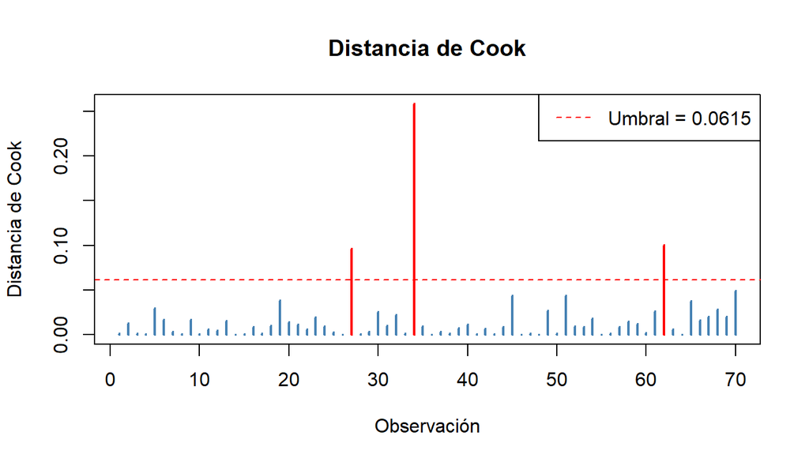

```r
# Gráfico de distancia de Cook
plot(dist_cook,
  type = "h", main = "Distancia de Cook",
  ylab = "Distancia de Cook", xlab = "Observación",
  col = ifelse(dist_cook > umbral_cook, "red", "steelblue"), lwd = 2
)
abline(h = umbral_cook, col = "red", lty = 2)
legend("topright",
  legend = paste("Umbral =", round(umbral_cook, 4)),
  col = "red", lty = 2
)
```

### Leverage (Apalancamiento)

Se evalúan los valores hat (leverage) para detectar observaciones con alto apalancamiento. El umbral se define como $\frac{2(k+1)}{n}$.

```r
hat_values <- hatvalues(modelo_rlm)
umbral_hat <- 2 * (k + 1) / n

cat("=== Casos con alto apalancamiento ===\n")
```

```
## === Casos con alto apalancamiento ===
```

```r
cat("Umbral leverage:", round(umbral_hat, 4), "\n\n")
```

```
## Umbral leverage: 0.1429
```

```r
alto_leverage <- which(hat_values > umbral_hat)
if (length(alto_leverage) > 0) {
  cat(
    "Se encontraron", length(alto_leverage),
    "caso(s) con alto apalancamiento:\n"
  )
  for (idx in alto_leverage) {
    cat("  Fila", idx, "- Leverage:", round(hat_values[idx], 4), "\n")
  }
} else {
  cat("No se encontraron casos con alto apalancamiento.\n")
}
```

```
## Se encontraron 4 caso(s) con alto apalancamiento:
##   Fila 27 - Leverage: 0.2216
##   Fila 34 - Leverage: 0.1499
##   Fila 40 - Leverage: 0.1714
##   Fila 62 - Leverage: 0.1665
```

## 7.3 Condiciones para Regresión Lineal Simple (RLS)

La pauta también pide evaluar la generalidad (condiciones) del modelo de RLS, no solo del RLM. Como el modelo simple tiene un único predictor, no aplica la condición de multicolinealidad.

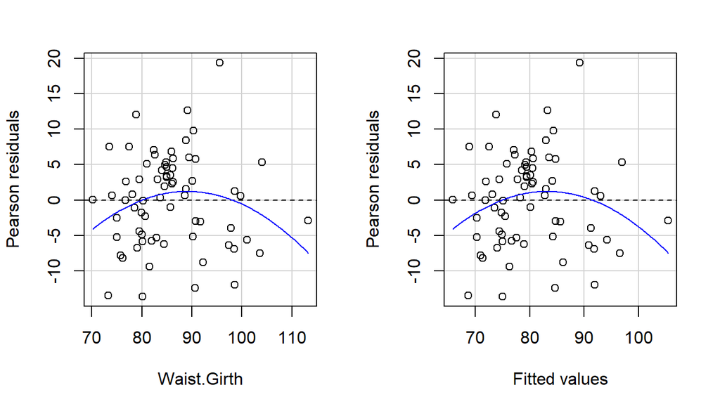

```
##             Test stat Pr(>|Test stat|)
## Waist.Girth   -1.8829          0.06406 .
## Tukey test    -1.8829          0.05971 .
## ---
## Signif. codes:  0 '***' 0.001 '**' 0.01 '*' 0.05 '.' 0.1 ' ' 1
```

```r
library(car)

# Linealidad
residualPlots(modelo_base, fitted = TRUE)
```

```r
# Independencia
cat("=== Test de Durbin-Watson (RLS) ===\n")
```

```
## === Test de Durbin-Watson (RLS) ===
```

```r
dw_test_rls <- durbinWatsonTest(modelo_base)
print(dw_test_rls)
```

```
##  lag Autocorrelation D-W Statistic p-value
##    1     -0.03091896      2.051563    0.82
##  Alternative hypothesis: rho != 0
```

```r
cat(
  "\nConclusión:", ifelse(dw_test_rls$p > 0.05,
    "No se rechaza H0, los residuos son independientes",
    "Se rechaza H0, existe autocorrelación en los residuos"
  ),
  "(p =", round(dw_test_rls$p, 4), ")\n\n"
)
```

```
##
## Conclusión: No se rechaza H0, los residuos son independientes (p = 0.82 )
```

```r
# Normalidad
cat("=== Test de Shapiro-Wilk (RLS) ===\n")
```

```
## === Test de Shapiro-Wilk (RLS) ===
```

```r
shapiro_test_rls <- shapiro.test(residuals(modelo_base))
print(shapiro_test_rls)
```

```
##
##  Shapiro-Wilk normality test
##
## data:  residuals(modelo_base)
## W = 0.98566, p-value = 0.6069
```

```r
cat(
  "\nConclusión:", ifelse(shapiro_test_rls$p.value > 0.05,
    "No se rechaza H0, los residuos siguen una distribución normal",
    "Se rechaza H0, los residuos NO siguen una distribución normal"
  ),
  "(p =", round(shapiro_test_rls$p.value, 4), ")\n\n"
)
```

```
##
## Conclusión: No se rechaza H0, los residuos siguen una distribución normal (p = 0.6069 )
```

```r
# Homocedasticidad
cat("=== Test de homocedasticidad (ncvTest, RLS) ===\n")
```

```
## === Test de homocedasticidad (ncvTest, RLS) ===
```

```r
ncv_test_rls <- ncvTest(modelo_base)
print(ncv_test_rls)
```

```
## Non-constant Variance Score Test
## Variance formula: ~ fitted.values
## Chisquare = 0.5823125, Df = 1, p = 0.44541
```

```r
cat(
  "\nConclusión:", ifelse(ncv_test_rls$p > 0.05,
    "No se rechaza H0, hay homocedasticidad",
    "Se rechaza H0, hay heterocedasticidad"
  ),
  "(p =", round(ncv_test_rls$p, 4), ")\n\n"
)
```

```
##
## Conclusión: No se rechaza H0, hay homocedasticidad (p = 0.4454 )
```

## 7.4 Condiciones para Regresión Lineal Múltiple (RLM)

Se verifican las condiciones necesarias para que el modelo de RLM sea válido.

### Condición 1: Linealidad de la relación

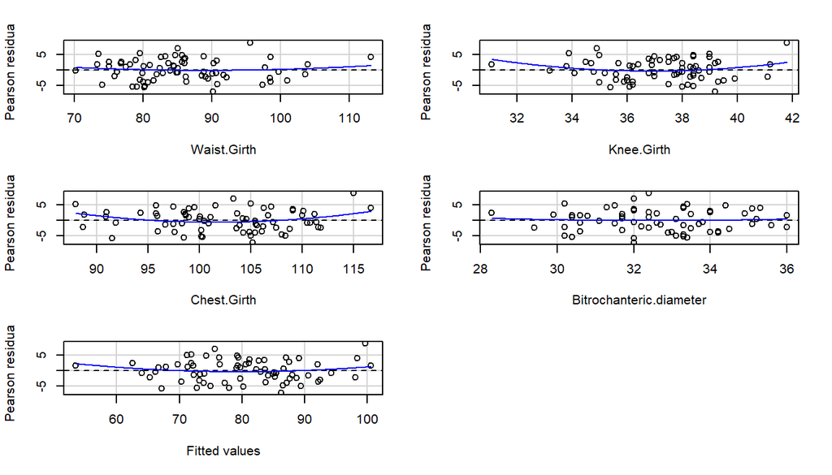

```
##                         Test stat Pr(>|Test stat|)
## Waist.Girth                0.6367          0.52660
## Knee.Girth                 1.5688          0.12163
## Chest.Girth                1.9864          0.05127 .
## Bitrochanteric.diameter    0.3235          0.74739
## Tukey test                 1.1251          0.26056
## ---
## Signif. codes:  0 '***' 0.001 '**' 0.01 '*' 0.05 '.' 0.1 ' ' 1
```

```r
library(car)
residualPlots(
  modelo_rlm,
  terms = ~ Waist.Girth + Knee.Girth + Chest.Girth + Bitrochanteric.diameter,
  fitted = TRUE
)
```

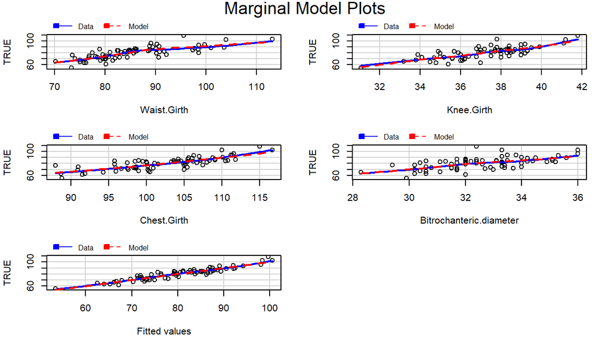

```r
marginalModelPlots(
  modelo_rlm,
  terms = ~ Waist.Girth + Knee.Girth + Chest.Girth + Bitrochanteric.diameter
)
```

### Condición 2: Independencia de los residuos

Se utiliza el test de Durbin-Watson para evaluar la independencia de los residuos.

```r
library(car)
cat("=== Test de Durbin-Watson ===\n")
```

```
## === Test de Durbin-Watson ===
```

```r
dw_test <- durbinWatsonTest(modelo_rlm)
print(dw_test)
```

```
##  lag Autocorrelation D-W Statistic p-value
##    1     -0.07590799      2.115562   0.648
##  Alternative hypothesis: rho != 0
```

```r
if (dw_test$p > 0.05) {
  cat(
    "\nConclusión: No se rechaza H0, los residuos son independientes (p =",
    round(dw_test$p, 4), ")\n"
  )
} else {
  cat(
    "\nConclusión: Se rechaza H0, existe autocorrelación en los residuos (p =",
    round(dw_test$p, 4), ")\n"
  )
}
```

```
##
## Conclusión: No se rechaza H0, los residuos son independientes (p = 0.648 )
```

### Condición 3: Normalidad de los residuos

Se evalúa la normalidad de los residuos mediante el test de Shapiro-Wilk y un Q-Q plot.

```r
cat("=== Test de Shapiro-Wilk para normalidad de los residuos ===\n")
```

```
## === Test de Shapiro-Wilk para normalidad de los residuos ===
```

```r
shapiro_test <- shapiro.test(residuals(modelo_rlm))
print(shapiro_test)
```

```
##
##  Shapiro-Wilk normality test
##
## data:  residuals(modelo_rlm)
## W = 0.98725, p-value = 0.7011
```

```r
if (shapiro_test$p.value > 0.05) {
  cat(
    "\nConclusión: No se rechaza H0, los residuos siguen una distribución",
    "normal (p =", round(shapiro_test$p.value, 4), ")\n"
  )
} else {
  cat(
    "\nConclusión: Se rechaza H0, los residuos NO siguen una distribución",
    "normal (p =", round(shapiro_test$p.value, 4), ")\n"
  )
}
```

```
##
## Conclusión: No se rechaza H0, los residuos siguen una distribución normal (p = 0.7011 )
```

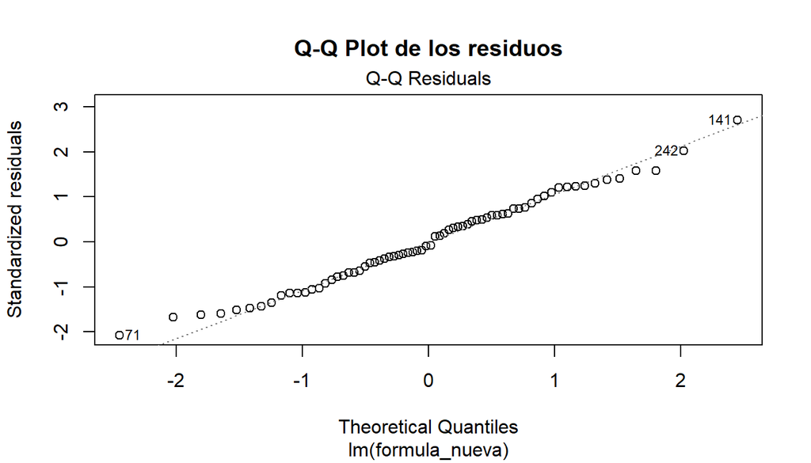

```r
# Q-Q plot
plot(modelo_rlm, which = 2, main = "Q-Q Plot de los residuos")
```

### Condición 4: Homocedasticidad (varianza constante)

Se evalúa la homocedasticidad con ncvTest.

```r
cat("=== Test de homocedasticidad (ncvTest) ===\n")
```

```
## === Test de homocedasticidad (ncvTest) ===
```

```r
ncv_test <- ncvTest(modelo_rlm)
print(ncv_test)
```

```
## Non-constant Variance Score Test
## Variance formula: ~ fitted.values
## Chisquare = 0.8745566, Df = 1, p = 0.3497
```

```r
if (ncv_test$p > 0.05) {
  cat(
    "\nConclusión: No se rechaza H0, hay homocedasticidad (p =",
    round(ncv_test$p, 4), ")\n"
  )
} else {
  cat(
    "\nConclusión: Se rechaza H0, hay heterocedasticidad (p =",
    round(ncv_test$p, 4), ")\n"
  )
}
```

```
##
## Conclusión: No se rechaza H0, hay homocedasticidad (p = 0.3497 )
```

### Condición 5: Ausencia de multicolinealidad

Se verifica la multicolinealidad entre los predictores mediante el Factor de Inflación de la Varianza (VIF). Valores de VIF mayores a 5 sugieren problemas de multicolinealidad.

```r
cat("=== Factor de Inflación de la Varianza (VIF) ===\n")
```

```
## === Factor de Inflación de la Varianza (VIF) ===
```

```r
vif_valores <- vif(modelo_rlm)
print(vif_valores)
```

```
##             Waist.Girth              Knee.Girth             Chest.Girth
##                2.269305                1.674586                1.861481
## Bitrochanteric.diameter
##                1.662564
```

```r
if (any(vif_valores > 5)) {
  cat(
    "\n¡ADVERTENCIA! Los siguientes predictores presentan alta",
    "multicolinealidad (VIF > 5):\n"
  )
  problematicos <- names(vif_valores[vif_valores > 5])
  for (pred in problematicos) {
    cat("  -", pred, ": VIF =", round(vif_valores[pred], 2), "\n")
  }
} else {
  cat(
    "\nNo se detectan problemas de multicolinealidad",
    "(todos los VIF < 5).\n"
  )
}
```

```
##
## No se detectan problemas de multicolinealidad (todos los VIF < 5).
```

## 7.5 Corrección del modelo

Si se detectan problemas, se procede a corregir el modelo eliminando casos atípicos e influyentes problemáticos, y se reevalúan las condiciones.

```r
# Identificar casos a eliminar: atípicos e influyentes simultáneamente
casos_problematicos <- union(atipicos, influyentes)

cat("=== Casos problemáticos identificados ===\n")
```

```
## === Casos problemáticos identificados ===
```

```r
cat("Casos atípicos:", length(atipicos), "\n")
```

```
## Casos atípicos: 0
```

```r
cat("Casos influyentes:", length(influyentes), "\n")
```

```
## Casos influyentes: 3
```

```r
cat("Total de casos problemáticos (únicos):", length(casos_problematicos), "\n")
```

```
## Total de casos problemáticos (únicos): 3
```

```r
# Verificar que no se elimina más del 10% de los datos
porcentaje_eliminado <- length(casos_problematicos) / n * 100
cat("Porcentaje de datos a eliminar:", round(porcentaje_eliminado, 1), "%\n\n")
```

```
## Porcentaje de datos a eliminar: 4.3 %
```

```r
if (length(casos_problematicos) > 0 & porcentaje_eliminado <= 10) {
  cat("Se procede a eliminar los casos problemáticos y reajustar el modelo.\n\n")

  datos_limpios <- datos_modelado[-casos_problematicos, ]
  cat("Observaciones originales:", n, "\n")
  cat("Observaciones después de limpieza:", nrow(datos_limpios), "\n\n")

  # Reajustar el modelo con los datos limpios
  modelo_corregido <- update(modelo_rlm, data = datos_limpios)

  cat("=== Modelo corregido ===\n")
  print(summary(modelo_corregido))

  cat("\n=== Comparación de modelos ===\n")
  cat("R² ajustado original:", round(summary(modelo_rlm)$adj.r.squared, 4), "\n")
  cat("R² ajustado corregido:", round(summary(modelo_corregido)$adj.r.squared, 4), "\n")
  cat("AIC original:", round(AIC(modelo_rlm), 2), "\n")
  cat("AIC corregido:", round(AIC(modelo_corregido), 2), "\n")
} else if (porcentaje_eliminado > 10) {
  cat("Se eliminaría más del 10% de los datos.\n")
  cat("Se opta por eliminar solo los casos más extremos.\n\n")

  # Eliminar solo los atípicos (residuo estandarizado > 3)
  if (length(atipicos) > 0) {
    datos_limpios <- datos_modelado[-atipicos, ]
    modelo_corregido <- update(modelo_rlm, data = datos_limpios)

    cat("=== Modelo corregido (solo atípicos eliminados) ===\n")
    print(summary(modelo_corregido))
  } else {
    cat("No hay casos atípicos para eliminar. El modelo se mantiene.\n")
    modelo_corregido <- modelo_rlm
    datos_limpios <- datos_modelado
  }
} else {
  cat("No se encontraron casos problemáticos. El modelo se mantiene.\n")
  modelo_corregido <- modelo_rlm
  datos_limpios <- datos_modelado
}
```

```
## Se procede a eliminar los casos problemáticos y reajustar el modelo.
##
## Observaciones originales: 70
## Observaciones después de limpieza: 67
##
## === Modelo corregido ===
##
## Call:
## lm(formula = formula_nueva, data = datos_limpios)
##
## Residuals:
##     Min      1Q  Median      3Q     Max
## -6.1101 -1.7520  0.0801  2.4964  6.7816
##
## Coefficients:
##                          Estimate Std. Error t value Pr(>|t|)
## (Intercept)             -109.1662    10.0108 -10.905 4.72e-16 ***
## Waist.Girth                0.2058     0.0778   2.645 0.010324 *
## Knee.Girth                 1.5990     0.2860   5.591 5.40e-07 ***
## Chest.Girth                0.7084     0.0869   8.152 2.16e-11 ***
## Bitrochanteric.diameter    1.2066     0.3154   3.826 0.000305 ***
## ---
## Signif. codes:  0 '***' 0.001 '**' 0.01 '*' 0.05 '.' 0.1 ' ' 1
##
## Residual standard error: 3.296 on 62 degrees of freedom
## Multiple R-squared:  0.8817, Adjusted R-squared:  0.8741
## F-statistic: 115.5 on 4 and 62 DF,  p-value: < 2.2e-16
##
##
## === Comparación de modelos ===
## R² ajustado original: 0.8771
## R² ajustado corregido: 0.8741
## AIC original: 382.62
## AIC corregido: 356.76
```

### Reevaluación de condiciones del modelo corregido

```r
cat("=== Reevaluación de condiciones del modelo corregido ===\n\n")
```

```
## === Reevaluación de condiciones del modelo corregido ===
```

```r
# Normalidad
cat("--- Test de Shapiro-Wilk ---\n")
```

```
## --- Test de Shapiro-Wilk ---
```

```r
shapiro_corr <- shapiro.test(residuals(modelo_corregido))
print(shapiro_corr)
```

```
##
##  Shapiro-Wilk normality test
##
## data:  residuals(modelo_corregido)
## W = 0.97741, p-value = 0.2617
```

```r
cat(
  "Conclusión:", ifelse(shapiro_corr$p.value > 0.05,
    "Residuos normales", "Residuos NO normales"
  ),
  "(p =", round(shapiro_corr$p.value, 4), ")\n\n"
)
```

```
## Conclusión: Residuos normales (p = 0.2617 )
```

```r
# Homocedasticidad
cat("--- Test de homocedasticidad ---\n")
```

```
## --- Test de homocedasticidad ---
```

```r
ncv_corr <- ncvTest(modelo_corregido)
print(ncv_corr)
```

```
## Non-constant Variance Score Test
## Variance formula: ~ fitted.values
## Chisquare = 0.05533124, Df = 1, p = 0.81403
```

```r
cat(
  "Conclusión:", ifelse(ncv_corr$p > 0.05,
    "Homocedasticidad", "Heterocedasticidad"
  ),
  "(p =", round(ncv_corr$p, 4), ")\n\n"
)
```

```
## Conclusión: Homocedasticidad (p = 0.814 )
```

```r
# Independencia
cat("--- Test de Durbin-Watson ---\n")
```

```
## --- Test de Durbin-Watson ---
```

```r
dw_corr <- durbinWatsonTest(modelo_corregido)
print(dw_corr)
```

```
##  lag Autocorrelation D-W Statistic p-value
##    1      -0.1650464       2.29177   0.292
##  Alternative hypothesis: rho != 0
```

```r
cat(
  "Conclusión:", ifelse(dw_corr$p > 0.05,
    "Residuos independientes", "Autocorrelación detectada"
  ),
  "(p =", round(dw_corr$p, 4), ")\n\n"
)
```

```
## Conclusión: Residuos independientes (p = 0.292 )
```

```r
# Multicolinealidad
cat("--- VIF ---\n")
```

```
## --- VIF ---
```

```r
vif_corr <- vif(modelo_corregido)
print(vif_corr)
```

```
##             Waist.Girth              Knee.Girth             Chest.Girth
##                2.149441                1.785636                1.627233
## Bitrochanteric.diameter
##                1.763505
```

```r
cat("Conclusión:", ifelse(all(vif_corr < 5),
  "Sin problemas de multicolinealidad",
  "Problemas de multicolinealidad detectados"
), "\n\n")
```

```
## Conclusión: Sin problemas de multicolinealidad
```

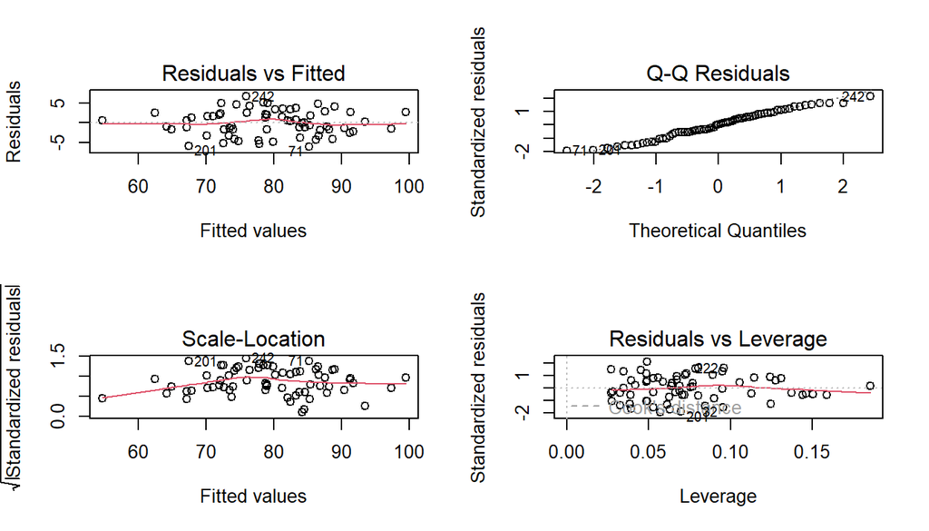

```r
# Gráficos diagnósticos del modelo corregido
par(mfrow = c(2, 2))
plot(modelo_corregido)
```

```r
par(mfrow = c(1, 1))
```

# Parte 8

Para evaluar la calidad predictiva se utilizan los 30 hombres que no participaron en la construcción de los modelos.

Siguiendo el capítulo 14, se calculan tres medidas:

- **RMSE:** representa el tamaño típico de los errores de predicción, medido en kilogramos. Un valor menor es mejor.
- **MAE:** corresponde al error promedio, sin considerar su signo, también medido en kilogramos. Un valor menor es mejor.
- **R cuadrado:** muestra qué tan bien las predicciones reproducen las diferencias observadas en el peso. Un valor más cercano a 1 es mejor.

Se comparará el modelo de regresión lineal simple con el modelo de regresión lineal múltiple.

```r
# Se mantiene el modelo RLM original porque la eliminación de los
# casos influyentes no se encuentra suficientemente justificada.

modelo_final <- modelo_rlm

# Predicciones del modelo lineal simple
predicciones_rls <- predict(
  modelo_base,
  newdata = datos_evaluacion
)

# Predicciones del modelo lineal múltiple
predicciones_rlm <- predict(
  modelo_final,
  newdata = datos_evaluacion
)
```

Se crea una función para calcular las medidas usadas para evaluar las predicciones.

```r
# Función para evaluar las predicciones
evaluar_predicciones <- function(observado, predicho) {

  errores <- observado - predicho

  data.frame(
    RMSE = sqrt(
      mean(errores^2)
    ),

    Rsquared = cor(
      observado,
      predicho
    )^2,

    MAE = mean(
      abs(errores)
    )
  )
}
```

Se calculan las medidas para ambos modelos utilizando exactamente los mismos 30 casos.

```r
# Resultados del RLS
metricas_rls <- evaluar_predicciones(
  observado = datos_evaluacion$Weight,
  predicho = predicciones_rls
)

# Resultados del RLM
metricas_rlm <- evaluar_predicciones(
  observado = datos_evaluacion$Weight,
  predicho = predicciones_rlm
)

# Tabla comparativa
comparacion_predictiva <- rbind(
  RLS = metricas_rls,
  RLM = metricas_rlm
)

comparacion_predictiva <- round(
  comparacion_predictiva,
  digits = 3
)

print(comparacion_predictiva)
```

```
##      RMSE Rsquared   MAE
## RLS 5.570    0.732 4.367
## RLM 4.956    0.842 4.166
```

También se muestra el peso real, el peso predicho por el RLM y el error cometido en cada uno de los 30 casos.

```r
resultados_evaluacion <- data.frame(
  Peso_observado = datos_evaluacion$Weight,
  Peso_predicho = predicciones_rlm,
  Error = datos_evaluacion$Weight -
    predicciones_rlm
)

resultados_evaluacion$Peso_predicho <- round(
  resultados_evaluacion$Peso_predicho,
  2
)

resultados_evaluacion$Error <- round(
  resultados_evaluacion$Error,
  2
)

print(resultados_evaluacion)
```

```
##     Peso_observado Peso_predicho  Error
## 232           82.3         87.33  -5.03
## 58            76.8         80.56  -3.76
## 146           80.2         80.95  -0.75
## 160           70.5         69.74   0.76
## 209           72.3         78.60  -6.30
## 30            60.9         57.82   3.08
## 38            61.3         66.18  -4.88
## 20            85.9         88.29  -2.39
## 91            70.2         66.43   3.77
## 127           85.5         79.52   5.98
## 169           96.8        101.91  -5.11
## 93            70.5         73.96  -3.46
## 156           68.6         66.31   2.29
## 69           101.6         96.25   5.35
```

[output cut: 16 more lines]

El siguiente gráfico permite comparar los pesos reales y predichos. Los puntos cercanos a la línea diagonal representan predicciones más acertadas.

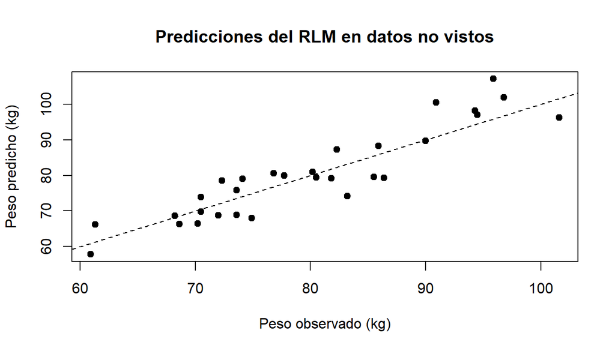

```r
plot(
  datos_evaluacion$Weight,
  predicciones_rlm,
  xlab = "Peso observado (kg)",
  ylab = "Peso predicho (kg)",
  main = "Predicciones del RLM en datos no vistos",
  pch = 19
)

abline(
  a = 0,
  b = 1,
  lty = 2
)
```

En los 30 casos no utilizados para construir los modelos, el RLS obtuvo un RMSE de 5.57 kg, un MAE de 4.367 kg y un R cuadrado de 0.732.

El RLM obtuvo un RMSE de 4.956 kg, un MAE de 4.166 kg y un R cuadrado de 0.842.

El modelo de regresión lineal múltiple presenta una mejor calidad predictiva que el modelo simple, porque comete errores menores y reproduce mejor las diferencias observadas en el peso. Por lo tanto, agregar los predictores seleccionados mejoró la predicción en los datos no vistos.

# Conclusiones

El modelo de RLS con `Waist.Girth` como predictor resultó confiable, aunque con un ajuste bastante más modesto que el del RLM (AIC = 465,92 frente a 382,62). Los residuos son independientes (Durbin-Watson, p=0,82), siguen una distribución normal (Shapiro-Wilk, p=0,607) y la varianza es homogénea (ncvTest, p=0,445). La linealidad quedó en el límite, es decir, la prueba de Tukey dio p=0,060, que no permite rechazar la linealidad al nivel habitual de 0,05, pero está cerca del umbral, por lo que conviene no descartar cierta curvatura leve en la relación entre `Waist.Girth` y `Weight`. Se encontró un caso atípico (fila 34, residuo estandarizado=3,008, justo sobre el umbral) y 4 casos influyentes según la distancia de Cook (filas 5, 34, 40 y 63), un número mayor que los 3 casos influyentes detectados en el RLM. Esto sugiere que el modelo simple es algo más sensible a observaciones puntuales que el modelo múltiple, lo que refuerza la conveniencia de usar el RLM.

A partir de ese modelo de RLS, la incorporación mediante selección hacia adelante (basada en AIC) de las variables `Knee.Girth`, `Chest.Girth` y `Bitrochanteric.diameter` mejoró sustancialmente el ajuste del modelo: el R² ajustado aumentó y el AIC se redujo de 465,92 (RLS) a 382,62 (RLM), demostrando que estos predictores aportan información relevante para explicar el peso más allá del contorno de cintura.

Al evaluar la capacidad predictiva en los 30 casos reservados y no usados para construir los modelos, el RLM superó al RLS en las tres métricas: menor RMSE (4,96 kg frente a 5,57 kg), menor MAE (4,17 kg frente a 4,37 kg) y mayor R² (0,842 frente a 0,732). Esto confirma que la mejora observada en el ajuste no se debió a un sobreajuste a los datos de entrenamiento, sino que se traduce en mejores predicciones sobre datos no vistos.

Se concluye que el modelo de RLM que predice el peso a partir del contorno de cintura, contorno de rodilla, contorno de pecho y diámetro bitrocantéreo es confiable y posee mejor poder predictivo que el modelo de RLS basado únicamente en el contorno de cintura, por lo que se recomienda su uso por sobre el modelo simple.

# Referencias

Jara, J. L., & Köhler, J. (s. f.). Inferencia y modelos estadísticos [Perusall].

Heinz, G., Peterson, L. J., Johnson, R. W., & Kerk, C. J. (2003). Exploring Relationships in Body Dimensions. Journal Of Statistics Education, 11(2). https://doi.org/10.1080/10691898.2003.11910711